# Analysis of Women Primary School Completion Rate

# Introduction

Nowadays, as is posted by J.P. Morgan research, the probability of the global economy recession by the end of 2024 is estimated to be 35%, which is a relatively higher chance comparing with 25%, the probability by the end of 2023. Therefore, it's more and more important to figure out ways to promote economic growth. The increase of female primary school completion rate is one of them. As defined by DataBank, female primary school completion rate is the population of girls that newly entering the last grade of primary school divided by the population of girls of their same age. This indicator doesn't count repeaters or those who drop from the last grade, but it's enough for us to take a look into how much the ratio of female primary school completion has changed over years and other factors. As mentioned in the webpage of Millenium Challenge Corporation, it's proven that there exists strong positive correlation between female primary school completion rate and promoted economic growth.  
This is a tutorial to walk through the lifecycle of data science. The main parts of the lifecycle includes:

- Data collection
- Data processing
- Exploratory analysis and data visualization
- Analysis, hypothesis testing and Machine Learning
- Insight and policy decision

## Importing libraries

Before we start collecting data, we need to import the required libraries, which enables us apply pre-written functions and saves our time. Usually in a whole data science lifecycle, this part does not need to be completed at first since we always realize the lack of library after a runtime error of unknown operation is reported. However, as a tutorial, this part appears in the first place.

```python
import numpy as np                                 # library for operations on large amount of data
import pandas as pd                                # library for operations on dataframes
import matplotlib.pyplot as plt                    # library for plotting the data, important to data visualization
from statsmodels.formula.api import ols            # library for assessing how much linear models fit correspnding data
from sklearn.linear_model import LinearRegression  # library for building a linear regression model to predict rate in the future.
```

Numpy and pandas are fundamental libraries in a data science lifecycle. They both deal with huge amount of data, but numpy focus on the mathematical operations of every element in the data structure, while pandas focus more on the changing of shape and size of dataframes. Matplotlib is a powerful library which plot the data, as its name tells. Therefore, it's crucial to data visualization. The OLS API provides us with values from a lot of aspects, such as R-squared value and p-value, the former one tells how much variance is explained by the model built, and the latter one tells how much the coefficients are fitting the scatters.

# Data Collection

This part is simply collecting data. In this tutorial, we need 5 tables, which I've already included in the Git folder.  
From my perspective, the female primary completion rate might be correlated to three variables, so I list them as features, they are the total primary completion rate, female primary school enrollment, and GDP per capita. The first one I select as feature is because if the total rate is high, it generally indicates strong educational infrastructure, policies, and cultural support for education, benefiting girls as well. The second one I select as a feature is for the reason thatmore girls enrolling in primary school increases the pool of potential completers. The third one is also a feature to the target, the reason for choosing GDP per capita is not so direct as the first two features. Countries with higher GDP per capita are with better economical conditions, so they can build more schools, improve transportation, and ensure safe environments for girls, encouraging attendance and completion.  
Besides, I also include a table of nations, in order to divide different countries into groups of their corresponding regions and income groups.  
In all, there are The five required tables are:

- Primary completion rate, female (% of relevant age group) (the target, abbreviated as womed)
- Primary completion rate, total (% of relevant age group) (one feature, abbreviated as alled)
- School enrollment, primary, female (% gross) (one feature, abbreviated as womse)
- GDP per capita, PPP (current international $) (one feature, abbreviated as gdppc)
- countries (a helper table to provide evidence for classifying different countries, either by region or by income group, abbreviated as ctry)

Since the data has not been merged into one dataframe, I add a prefix "data_" to all the abbreviations mentioned above.  
All tables are got from Comma-Separated Values (csv) files, pandas already contains a function called "read_csv" to convert from csv files to dataframes.  
The following are the first row of each table. I use the "skiprows" to skip the headers of all tables, otherwise the csv reader will confuse how many columns to read and convert as a dataframe since each header only include 2 columns, the strings "Data Source" and "World Development Indicators", which are not we mainly study in this tutorial.

```python
# table of primary completion rate, total
data_alled = pd.read_csv("all_education_data.csv", skiprows=3)
data_alled.head(1)
```

|  | Country Name | Country Code | Indicator Name | Indicator Code | 1960 | 1961 | 1962 | 1963 | 1964 | 1965 | ... | 2015 | 2016 | 2017 | 2018 | 2019 | 2020 | 2021 | 2022 | 2023 | Unnamed: 68 |
| --- | --- | --- | --- | --- | --- | --- | --- | --- | --- | --- | --- | --- | --- | --- | --- | --- | --- | --- | --- | --- | --- |
| 0 | Aruba | ABW | Primary completion rate, total (% of relevant ... | SE.PRM.CMPT.ZS | NaN | NaN | NaN | NaN | NaN | NaN | ... | NaN | NaN | NaN | 98.097252 | 108.233528 | 103.185188 | 100.936768 | 95.01976 | NaN | NaN |

1 rows × 69 columns

```python
# table of GDP per capita
data_gdppc = pd.read_csv("GDP_per_capita.csv", skiprows=3)
data_gdppc.head(1)
```

|  | Country Name | Country Code | Indicator Name | Indicator Code | 1960 | 1961 | 1962 | 1963 | 1964 | 1965 | ... | 2015 | 2016 | 2017 | 2018 | 2019 | 2020 | 2021 | 2022 | 2023 | Unnamed: 68 |
| --- | --- | --- | --- | --- | --- | --- | --- | --- | --- | --- | --- | --- | --- | --- | --- | --- | --- | --- | --- | --- | --- |
| 0 | Aruba | ABW | GDP per capita, PPP (current international $) | NY.GDP.PCAP.PP.CD | NaN | NaN | NaN | NaN | NaN | NaN | ... | 37231.918495 | 37444.441094 | 38697.949507 | 40379.293724 | 40124.757998 | 30437.202516 | 38226.146157 | 45236.021214 | NaN | NaN |

1 rows × 69 columns

```python
# table of primary completion rate, female
data_womed = pd.read_csv("women_education_data.csv", skiprows=3)
data_womed.head(1)
```

|  | Country Name | Country Code | Indicator Name | Indicator Code | 1960 | 1961 | 1962 | 1963 | 1964 | 1965 | ... | 2015 | 2016 | 2017 | 2018 | 2019 | 2020 | 2021 | 2022 | 2023 | Unnamed: 68 |
| --- | --- | --- | --- | --- | --- | --- | --- | --- | --- | --- | --- | --- | --- | --- | --- | --- | --- | --- | --- | --- | --- |
| 0 | Aruba | ABW | Primary completion rate, female (% of relevant... | SE.PRM.CMPT.FE.ZS | NaN | NaN | NaN | NaN | NaN | NaN | ... | NaN | NaN | NaN | 106.101189 | 107.025414 | 99.409157 | 103.091187 | 93.406593 | NaN | NaN |

1 rows × 69 columns

```python
# table of School enrollment, primary, female
data_womse = pd.read_csv("women_school_enrollment_data.csv", skiprows=3)
data_womse.head(1)
```

|  | Country Name | Country Code | Indicator Name | Indicator Code | 1960 | 1961 | 1962 | 1963 | 1964 | 1965 | ... | 2015 | 2016 | 2017 | 2018 | 2019 | 2020 | 2021 | 2022 | 2023 | Unnamed: 68 |
| --- | --- | --- | --- | --- | --- | --- | --- | --- | --- | --- | --- | --- | --- | --- | --- | --- | --- | --- | --- | --- | --- |
| 0 | Aruba | ABW | School enrollment, primary, female (% gross) | SE.PRM.ENRR.FE | NaN | NaN | NaN | NaN | NaN | NaN | ... | 116.41345 | NaN | NaN | 109.338722 | 109.263962 | 110.42865 | 113.950348 | 106.201759 | NaN | NaN |

1 rows × 69 columns

```python
# table of countries
data_ctry = pd.read_csv("countries_data.csv")
data_ctry.head(1)
```

|  | Country Code | Region | IncomeGroup | SpecialNotes | TableName | Unnamed: 5 |
| --- | --- | --- | --- | --- | --- | --- |
| 0 | ABW | Latin America & Caribbean | High income | NaN | Aruba | NaN |

# Data Processing

Since we only get five tables of raw data, we need to tidy them up before doing data analysis.  
First of all, we need to drop those columns of all null values, there's nothing to analyze for those years.  
"axis = 1" here means drop by columns.

```python
data_alled = data_alled.dropna(axis = 1, how = 'all')
data_gdppc = data_gdppc.dropna(axis = 1, how = 'all')
data_womed = data_womed.dropna(axis = 1, how = 'all')
data_womse = data_womse.dropna(axis = 1, how = 'all')
data_ctry = data_ctry.dropna(axis = 1, how = 'all')
```

Since I apply the same operation to all tables, only showing one of the first lines is enough to show the effect of the operation.

```python
data_alled.head(1)
```

|  | Country Name | Country Code | Indicator Name | Indicator Code | 1970 | 1971 | 1972 | 1973 | 1974 | 1975 | ... | 2014 | 2015 | 2016 | 2017 | 2018 | 2019 | 2020 | 2021 | 2022 | 2023 |
| --- | --- | --- | --- | --- | --- | --- | --- | --- | --- | --- | --- | --- | --- | --- | --- | --- | --- | --- | --- | --- | --- |
| 0 | Aruba | ABW | Primary completion rate, total (% of relevant ... | SE.PRM.CMPT.ZS | NaN | NaN | NaN | NaN | NaN | NaN | ... | 106.117989 | NaN | NaN | NaN | 98.097252 | 108.233528 | 103.185188 | 100.936768 | 95.01976 | NaN |

1 rows × 58 columns

After taking a close look at all tables, I've noticed that the table for GDP per capita only records data in and after the year of 1990. For the consistency, the data before 1990 of other three tables (excluding countries) also need to be dropped.

```python
# Drop columns from 1970 to 1989 for the other three dataframes
data_alled = data_alled.drop(data_alled.loc[:, '1970':'1989'].columns, axis=1)
data_womed = data_womed.drop(data_womed.loc[:, '1970':'1989'].columns, axis=1)
data_womse = data_womse.drop(data_womse.loc[:, '1970':'1989'].columns, axis=1)
data_womse.head(1)
```

|  | Country Name | Country Code | Indicator Name | Indicator Code | 1990 | 1991 | 1992 | 1993 | 1994 | 1995 | ... | 2014 | 2015 | 2016 | 2017 | 2018 | 2019 | 2020 | 2021 | 2022 | 2023 |
| --- | --- | --- | --- | --- | --- | --- | --- | --- | --- | --- | --- | --- | --- | --- | --- | --- | --- | --- | --- | --- | --- |
| 0 | Aruba | ABW | School enrollment, primary, female (% gross) | SE.PRM.ENRR.FE | NaN | NaN | NaN | NaN | NaN | NaN | ... | 117.00074 | 116.41345 | NaN | NaN | 109.338722 | 109.263962 | 110.42865 | 113.950348 | 106.201759 | NaN |

1 rows × 38 columns

There is a row with a country code which appears in all dataframes except the dataframe for country, it's called "INX", those unclassified countries. There are no data for such row in all four dataframes. However, I didn't choose to drop this line for the other four tables. The method I apply will appear later in this tutorial.

```python
set(data_alled['Country Code'])-(set(data_alled['Country Code']).intersection(set(data_ctry['Country Code'])))
```

```
{'INX'}
```

```python
[str(x) for x in range(1990,2024)];          # years from 1990 to 2023, delete the semicolon to see the output
```

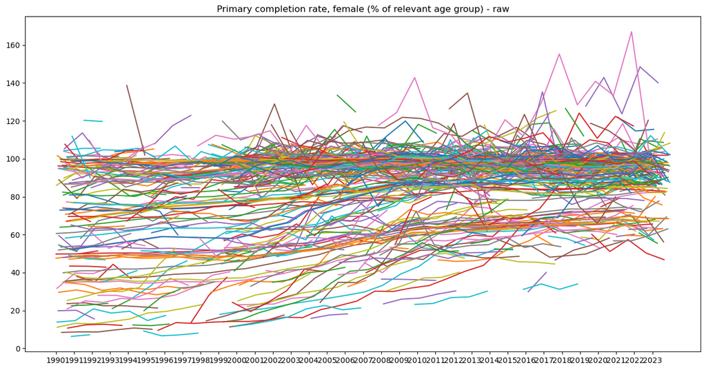

```python
# plot the data before further imputation of null values
unique_years, idx = np.unique(pd.melt(data_womed, id_vars=['Country Code','Indicator Name'],\
                                      value_vars=[str(x) for x in range(1990,2024)])['variable'].values,return_index=True)
plt.xticks(pd.melt(data_womed, id_vars=['Country Code','Indicator Name'],\
                   value_vars=[str(x) for x in range(1990,2024)]).index[idx], unique_years)
plt.title('Primary completion rate, female (% of relevant age group) - raw')
pd.melt(data_womed, id_vars=['Country Code','Indicator Name'], value_vars=\
        [str(x) for x in range(1990,2024)]).sort_values(['Country Code','variable'],\
                                                        ascending=True).groupby('Country Code')['value'].plot(figsize=(16,8))
plt.show()
```

Furthermore, the map plotting the recent available data globally is as following:

[figure not shown]

It's obvious that there are a lot of breaking points in the above plot, and reasonably fixing the points is the main purpose of this section.  
The next block is the same as what we've done so far, without showing the first line of each table. It is just for convenience of running the same process as a whole block.

```python
# initialize all the dataframes to "dirty" version to prevent unwanted inplace change
data_alled = pd.read_csv("all_education_data.csv", skiprows=3)
data_gdppc = pd.read_csv("GDP_per_capita.csv", skiprows=3)
data_womed = pd.read_csv("women_education_data.csv", skiprows=3)
data_womse = pd.read_csv("women_school_enrollment_data.csv", skiprows=3)
data_ctry = pd.read_csv("countries_data.csv")
data_alled = data_alled.dropna(axis = 1, how = 'all')
data_gdppc = data_gdppc.dropna(axis = 1, how = 'all')
data_womed = data_womed.dropna(axis = 1, how = 'all')
data_womse = data_womse.dropna(axis = 1, how = 'all')
data_ctry = data_ctry.dropna(axis = 1, how = 'all')
data_alled = data_alled.drop(data_alled.loc[:, '1970':'1989'].columns, axis=1).drop(['Country Name','Indicator Code'], axis=1)
data_womed = data_womed.drop(data_womed.loc[:, '1970':'1989'].columns, axis=1).drop(['Country Name','Indicator Code'], axis=1)
data_womse = data_womse.drop(data_womse.loc[:, '1970':'1989'].columns, axis=1).drop(['Country Name','Indicator Code'], axis=1)
```

Processing the data in dataframe of countries, including removing all redundant columns and fill the null values in the columns "Region" and "IncomeGroup" with '-' to escape from the operation "dropna" in pandas.

```python
# we don't need those two lines in the countries data, so drop them
data_ctry = data_ctry.drop(['SpecialNotes','TableName'], axis=1)
# those rows of areas, their region and Income Group are NaN. Fill them with '-'
# in case not get dropped by the operation 'dropna'
data_ctry[['Region','IncomeGroup']] = data_ctry[['Region','IncomeGroup']].fillna(value='-')
```

This block is what I've mentioned before, I left join dataframe of countries with other four dataframes, so the row with country code "INX" is eliminated automatically since it doesn't appear in the left table. After this operation, the number of rows for all five table becomes 265.

```python
data_womed = pd.merge(data_ctry, data_womed, on='Country Code', how='left')
data_womse = pd.merge(data_ctry, data_womse, on='Country Code', how='left')
data_alled = pd.merge(data_ctry, data_alled, on='Country Code', how='left')
data_gdppc = pd.merge(data_ctry, data_gdppc, on='Country Code', how='left')
```

```python
data_womed.shape
```

```
(265, 38)
```

Then we need to find and drop the countries without any data from 1990 to 2023 in any of the four tables excluding the table for countries, since no imputation can be done if no data appear for a whole row.

```python
# Since some of the countries don't have any data during 1990 and 2023 in any of the four tables,
# we need to find those countries and drop them from all four tables.

# rows of all NaN in female Primary completion rate
idx1 = data_womed.index[data_womed[[str(x) for x in range(1990,2024)]].isnull().all(1)]
# rows of all NaN in overall Primary completion rate
idx2 = data_alled.index[data_alled[[str(x) for x in range(1990,2024)]].isnull().all(1)]
# rows of all NaN in female school enrollment rate
idx3 = data_womse.index[data_womse[[str(x) for x in range(1990,2024)]].isnull().all(1)]
# rows of all NaN in GDP per capita
idx4 = data_gdppc.index[data_gdppc[[str(x) for x in range(1990,2024)]].isnull().all(1)]
rows_to_drop = list(set(idx1).union(set(idx2)).union(set(idx3)).union(set(idx4)))
```

```python
# drop those rows
data_womed = data_womed.drop(data_womed.index[rows_to_drop])
data_alled = data_alled.drop(data_alled.index[rows_to_drop])
data_womse = data_womse.drop(data_womse.index[rows_to_drop])
data_gdppc = data_gdppc.drop(data_gdppc.index[rows_to_drop])
```

```python
data_womed.head()
```

|  | Country Code | Region | IncomeGroup | Indicator Name | 1990 | 1991 | 1992 | 1993 | 1994 | 1995 | ... | 2014 | 2015 | 2016 | 2017 | 2018 | 2019 | 2020 | 2021 | 2022 | 2023 |
| --- | --- | --- | --- | --- | --- | --- | --- | --- | --- | --- | --- | --- | --- | --- | --- | --- | --- | --- | --- | --- | --- |
| 0 | ABW | Latin America & Caribbean | High income | Primary completion rate, female (% of relevant... | NaN | NaN | NaN | NaN | NaN | NaN | ... | 106.056129 | NaN | NaN | NaN | 106.101189 | 107.025414 | 99.409157 | 103.091187 | 93.406593 | NaN |
| 1 | AFE | - | - | Primary completion rate, female (% of relevant... | 47.559921 | 48.741920 | 47.698872 | 49.168579 | 48.006962 | 48.312119 | ... | 66.414238 | 66.434967 | 67.416733 | 68.639549 | 69.875000 | 70.373734 | 71.271111 | 72.304916 | 71.336227 | NaN |
| 2 | AFG | South Asia | Low income | Primary completion rate, female (% of relevant... | NaN | NaN | NaN | 17.072041 | NaN | NaN | ... | NaN | NaN | 65.567612 | 69.041924 | 69.766609 | 67.502800 | NaN | NaN | NaN | NaN |
| 3 | AFW | - | - | Primary completion rate, female (% of relevant... | 49.794651 | 49.846691 | 50.147141 | 50.284180 | 50.357540 | 50.240330 | ... | 63.280010 | 64.309517 | 64.928780 | 64.457779 | 64.781212 | 64.994743 | 65.438469 | 66.152931 | 64.926788 | 65.61779 |
| 4 | AGO | Sub-Saharan Africa | Lower middle income | Primary completion rate, female (% of relevant... | NaN | NaN | NaN | NaN | NaN | NaN | ... | NaN | NaN | NaN | NaN | NaN | NaN | NaN | 59.030548 | 60.200428 | NaN |

5 rows × 38 columns

Only reserve those rows with full values of GDP per capita. I make this decision because there are various reason for the missing values of GDP per capita. For example, Syria has not reported GDP per capita from 1990 to 2016, and no data reported since 2022 as well. During these years, Syria was deeply involved in wars. Therefore, for the ideal convenience, I choose not to consider these countries with null values of GDP per capita in any year between 1990 and 2023.

```python
rows_to_drop = list(data_gdppc.index[data_gdppc.isnull().any(axis=1)])
# drop those rows
data_womed = data_womed.drop(rows_to_drop,axis=0)
data_alled = data_alled.drop(rows_to_drop,axis=0)
data_womse = data_womse.drop(rows_to_drop,axis=0)
data_gdppc = data_gdppc.drop(rows_to_drop,axis=0)
```

```python
len(data_womed.index[data_womed.isnull().any(axis=1)])
```

```
187
```

Now there are still 187 rows in the "female primary completion rate" table contain null values. For this case, imputation with regressors regarding to GDP per capita as the univariate are not what we want. Even with decision tree which produces the highest coefficient of determination (score), the predicted values for imputation are exploding to over 400. Instead, we need a nearby value, so I use ffill to fill the empty space with the nearest available year.  
Another reason for applying $ffill$ but not $bfill$ is that I assume that one reason of why a country refuses to update any value might be that the newest value is almost the same as the current value but the latter value cannot be inferred as the value in the previous year because no one can reasonably infer what happened in the previous year.

```python
data_womed[[str(x) for x in range(1990,2024)]]=data_womed[[str(x) for x in range(1990,2024)]].ffill(axis = 1).infer_objects(copy=False)
data_womse[[str(x) for x in range(1990,2024)]]=data_womse[[str(x) for x in range(1990,2024)]].ffill(axis = 1).infer_objects(copy=False)
data_alled[[str(x) for x in range(1990,2024)]]=data_alled[[str(x) for x in range(1990,2024)]].ffill(axis = 1).infer_objects(copy=False)
data_womed.head()
```

|  | Country Code | Region | IncomeGroup | Indicator Name | 1990 | 1991 | 1992 | 1993 | 1994 | 1995 | ... | 2014 | 2015 | 2016 | 2017 | 2018 | 2019 | 2020 | 2021 | 2022 | 2023 |
| --- | --- | --- | --- | --- | --- | --- | --- | --- | --- | --- | --- | --- | --- | --- | --- | --- | --- | --- | --- | --- | --- |
| 1 | AFE | - | - | Primary completion rate, female (% of relevant... | 47.559921 | 48.741920 | 47.698872 | 49.168579 | 48.006962 | 48.312119 | ... | 66.414238 | 66.434967 | 67.416733 | 68.639549 | 69.875000 | 70.373734 | 71.271111 | 72.304916 | 71.336227 | 71.336227 |
| 3 | AFW | - | - | Primary completion rate, female (% of relevant... | 49.794651 | 49.846691 | 50.147141 | 50.284180 | 50.357540 | 50.240330 | ... | 63.280010 | 64.309517 | 64.928780 | 64.457779 | 64.781212 | 64.994743 | 65.438469 | 66.152931 | 64.926788 | 65.617790 |
| 4 | AGO | Sub-Saharan Africa | Lower middle income | Primary completion rate, female (% of relevant... | NaN | NaN | NaN | NaN | NaN | NaN | ... | 35.863651 | 35.863651 | 35.863651 | 35.863651 | 35.863651 | 35.863651 | 35.863651 | 59.030548 | 60.200428 | 60.200428 |
| 5 | ALB | Europe & Central Asia | Upper middle income | Primary completion rate, female (% of relevant... | NaN | NaN | NaN | NaN | NaN | NaN | ... | 106.871689 | 98.142700 | 99.869720 | 104.463074 | 102.025398 | 94.476189 | 97.040092 | 94.849289 | 97.502762 | 91.699600 |
| 6 | AND | Europe & Central Asia | High income | Primary completion rate, female (% of relevant... | NaN | NaN | NaN | NaN | NaN | NaN | ... | 65.675682 | 68.601578 | 64.207649 | 66.091949 | 62.359550 | 61.994610 | 61.643841 | 60.092812 | 60.092812 | 68.159203 |

5 rows × 38 columns

After that, I use melt to change the rows and columns of each dataframe.  
Melt is a function to rearrange the dataframe. Each row is with IDs of a variable and different values of the variable.  
In this case, I set the IDs as "Country Code", "Region", "IncomeGroup" and "Indicator Name", and the variables are those data from 1990 to 2023. After that, the data can be transformed to such a shape that the values each year for every country is in a single column. The convenience of this operation is shown shortly after this block.

```python
data_womed = pd.melt(data_womed, id_vars=['Country Code','Region','IncomeGroup','Indicator Name'],\
                     value_vars=[str(x) for x in range(1990,2024)]).sort_values(['Country Code','variable'],\
                                                                                ascending=True)
data_alled = pd.melt(data_alled, id_vars=['Country Code','Region','IncomeGroup','Indicator Name'],\
                     value_vars=[str(x) for x in range(1990,2024)]).sort_values(['Country Code','variable'],\
                                                                                ascending=True)
data_womse = pd.melt(data_womse, id_vars=['Country Code','Region','IncomeGroup','Indicator Name'],\
                     value_vars=[str(x) for x in range(1990,2024)]).sort_values(['Country Code','variable']\
                                                                                ,ascending=True)
data_gdppc = pd.melt(data_gdppc, id_vars=['Country Code','Region','IncomeGroup','Indicator Name'],\
                     value_vars=[str(x) for x in range(1990,2024)]).sort_values(['Country Code','variable'],\
                                                                                ascending=True)
data_womed.head()
```

|  | Country Code | Region | IncomeGroup | Indicator Name | variable | value |
| --- | --- | --- | --- | --- | --- | --- |
| 0 | AFE | - | - | Primary completion rate, female (% of relevant... | 1990 | 47.559921 |
| 217 | AFE | - | - | Primary completion rate, female (% of relevant... | 1991 | 48.741920 |
| 434 | AFE | - | - | Primary completion rate, female (% of relevant... | 1992 | 47.698872 |
| 651 | AFE | - | - | Primary completion rate, female (% of relevant... | 1993 | 49.168579 |
| 868 | AFE | - | - | Primary completion rate, female (% of relevant... | 1994 | 48.006962 |

Another function apply right after "melt" is "rename" since we cannot leave those columns as "variable" and "value" for every dataframe, otherwise "variable" and "value" are anbiguous. You can easily notice that I didn't drop the column "Indicator Name" but I also didn't mention its necessity. This point is where it is needed. I replace the column name "value" with the indicator name of each dataframe. Since the indicator name for every observation is the same in a dataframe, I only extract the first entry of the column "Indicator Name" to replace the column name "value". The name to replace "variable" is simply yearID. The "rename" function is also applied to all dataframes except dataframe of countries.

```python
data_womed.rename(columns={"variable": "yearID", "value": data_womed.loc[0,'Indicator Name']}, inplace = True)
data_alled.rename(columns={"variable": "yearID", "value": data_alled.loc[0,'Indicator Name']}, inplace = True)
data_gdppc.rename(columns={"variable": "yearID", "value": data_gdppc.loc[0,'Indicator Name']}, inplace = True)
data_womse.rename(columns={"variable": "yearID", "value": data_womse.loc[0,'Indicator Name']}, inplace = True)
```

```python
data_womed.head()
```

|  | Country Code | Region | IncomeGroup | Indicator Name | yearID | Primary completion rate, female (% of relevant age group) |
| --- | --- | --- | --- | --- | --- | --- |
| 0 | AFE | - | - | Primary completion rate, female (% of relevant... | 1990 | 47.559921 |
| 217 | AFE | - | - | Primary completion rate, female (% of relevant... | 1991 | 48.741920 |
| 434 | AFE | - | - | Primary completion rate, female (% of relevant... | 1992 | 47.698872 |
| 651 | AFE | - | - | Primary completion rate, female (% of relevant... | 1993 | 49.168579 |
| 868 | AFE | - | - | Primary completion rate, female (% of relevant... | 1994 | 48.006962 |

# Exploratory Analysis and Data Visualization

The following plot is the imputed version of girls' primary school completion rate of various regions and countries between 1990 and 2023. Since there are more than 50 of them in total, labeling them will make the plot extremely long, and I mention this plot here just for providing the big picture, which means that the labels are not as important as all the lines in the plot.  
It's obvious that after filling all null values with the previous value, the lines in this plot becomes reasonably continuous. By saying "reasonably", I mean that the lines are not immediately rising to a value of 600 with a large slope.  
Furthermore, by applying the function "plt.show()", I can avoid printing all the names of variables which take a lot of unnecessary space and lower the readability.

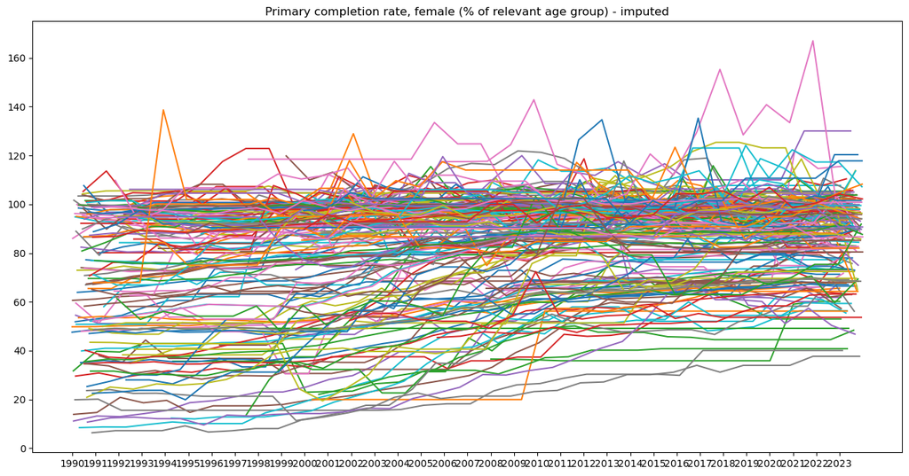

```python
unique_years, idx = np.unique(data_womed['yearID'].values,return_index=True)
plt.xticks(data_womed.index[idx], unique_years)
plt.title('Primary completion rate, female (% of relevant age group) - imputed')
ax = plt.gca()
data_womed.groupby('Country Code')['Primary completion rate, female (% of relevant age group)'].plot(figsize=(16,8))
plt.show()
```

```python
df = pd.concat([data_gdppc,data_alled.iloc[:,-1],data_womse.iloc[:,-1],data_womed.iloc[:,-1]],axis=1)
```

```python
df
```

|  | Country Code | Region | IncomeGroup | Indicator Name | yearID | GDP per capita, PPP (current international $) | Primary completion rate, total (% of relevant age group) | School enrollment, primary, female (% gross) | Primary completion rate, female (% of relevant age group) |
| --- | --- | --- | --- | --- | --- | --- | --- | --- | --- |
| 0 | AFE | - | - | GDP per capita, PPP (current international $) | 1990 | 1816.035866 | 51.859550 | 68.009560 | 47.559921 |
| 217 | AFE | - | - | GDP per capita, PPP (current international $) | 1991 | 1829.114493 | 52.631981 | 69.372131 | 48.741920 |
| 434 | AFE | - | - | GDP per capita, PPP (current international $) | 1992 | 1787.915919 | 51.509998 | 67.948502 | 47.698872 |
| 651 | AFE | - | - | GDP per capita, PPP (current international $) | 1993 | 1780.641370 | 52.728588 | 68.108559 | 49.168579 |
| 868 | AFE | - | - | GDP per capita, PPP (current international $) | 1994 | 1804.269969 | 51.338570 | 67.912148 | 48.006962 |
| ... | ... | ... | ... | ... | ... | ... | ... | ... | ... |
| 6509 | ZWE | Sub-Saharan Africa | Lower middle income | GDP per capita, PPP (current international $) | 2019 | 2711.529334 | 90.232155 | 96.285933 | 89.272163 |
| 6726 | ZWE | Sub-Saharan Africa | Lower middle income | GDP per capita, PPP (current international $) | 2020 | 2784.872395 | 91.866905 | 96.641973 | 91.124168 |
| 6943 | ZWE | Sub-Saharan Africa | Lower middle income | GDP per capita, PPP (current international $) | 2021 | 3276.267753 | 86.099625 | 95.467535 | 86.142853 |
| 7160 | ZWE | Sub-Saharan Africa | Lower middle income | GDP per capita, PPP (current international $) | 2022 | 3660.835501 | 86.116936 | 95.388789 | 86.648933 |
| 7377 | ZWE | Sub-Saharan Africa | Lower middle income | GDP per capita, PPP (current international $) | 2023 | 3899.899233 | 86.116936 | 95.388789 | 86.648933 |

7378 rows × 9 columns

# Hypothesis Testing

The first step of hypothesis testing is to raise hypotheses, in other words, guesses. I made two guesses before I build models to the data. To test these hypotheses, I use the results from the p-values of OLS summaries. For the convenience of constructing linear models, I rename the columns as a string without whitespace before building a linear model and drop those rows without specified region and income group.  
The first guess is that primary completion rate is related to the region.

```python
# plot a mean for every region
plot_df = df.loc[df['Region'] != '-'].groupby(["Region","yearID"])\
        [['GDP per capita, PPP (current international $)','Primary completion rate, female (% of relevant age group)']].aggregate("mean")
plot_df.head()
```

| Region | yearID | GDP per capita, PPP (current international $) | Primary completion rate, female (% of relevant age group) |
| --- | --- | --- | --- |
| East Asia & Pacific | 1990 | 7735.078136 | 88.889427 |
|  | 1991 | 8059.802819 | 89.078600 |
|  | 1992 | 8452.817690 | 83.452803 |
|  | 1993 | 8745.355041 | 90.127908 |
|  | 1994 | 9195.306836 | 87.101547 |

The next block is the order of unique regions.

```python
np.unique(df.loc[df['Region'] != '-']['Region'].values)
```

```
array(['East Asia & Pacific', 'Europe & Central Asia',
       'Latin America & Caribbean', 'Middle East & North Africa',
       'North America', 'South Asia', 'Sub-Saharan Africa'], dtype=object)
```

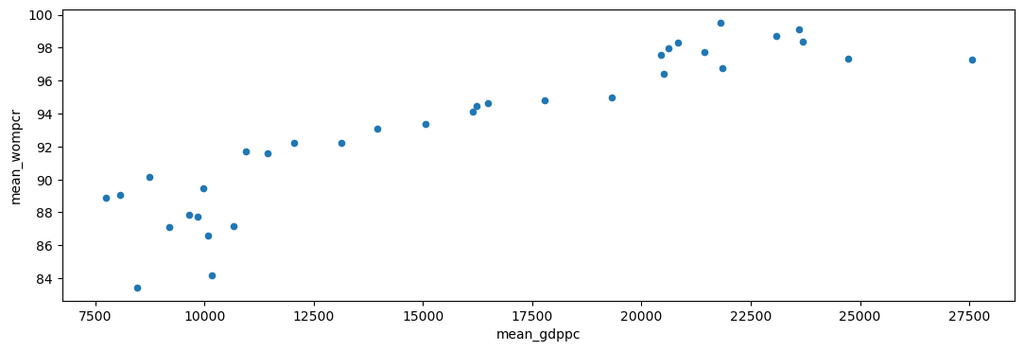

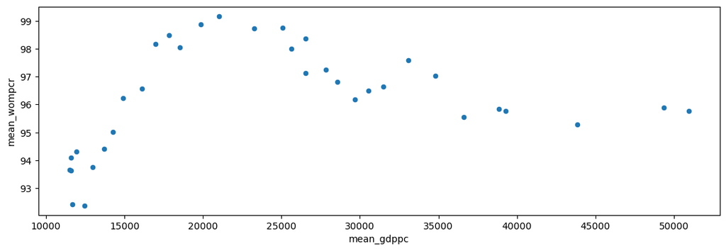

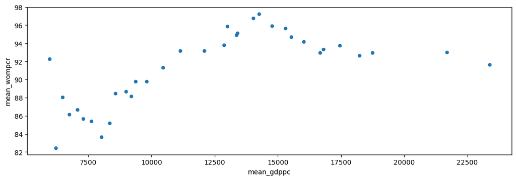

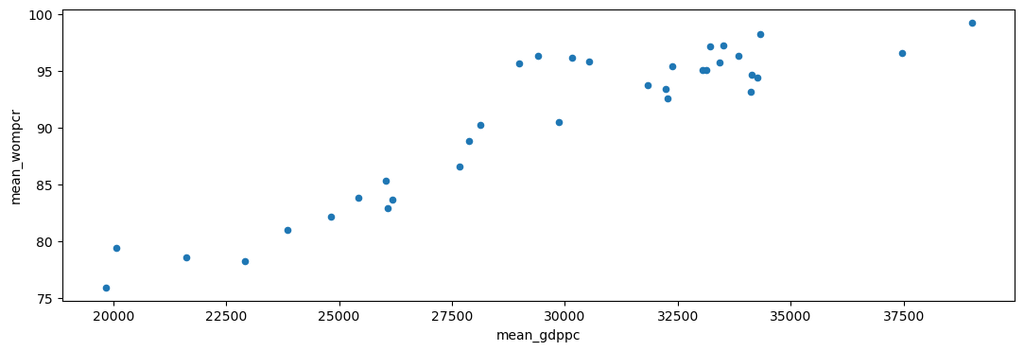

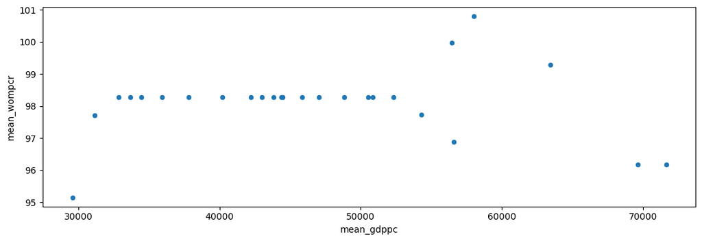

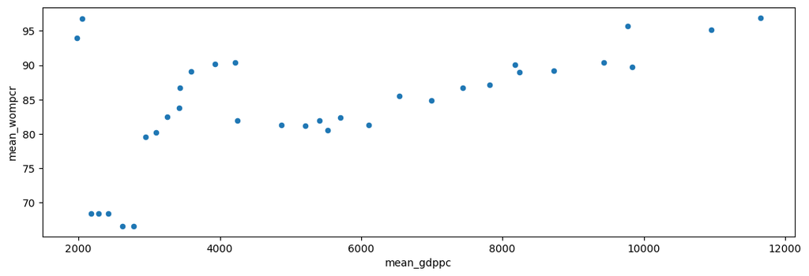

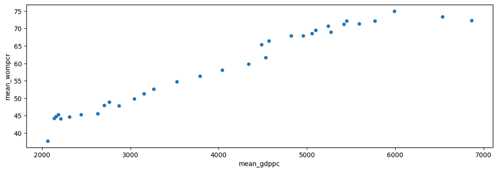

```python
plot_df.rename(columns={"GDP per capita, PPP (current international $)": "mean_gdppc",
                        "Primary completion rate, female (% of relevant age group)": "mean_wompcr"}, inplace = True)
plot_df.groupby('Region').plot.scatter(x='mean_gdppc',y='mean_wompcr',figsize=(13,4))
plt.show()
```

Check if there is linear relationship in those values between GDP per capita and female primary completion rate.  
Instead of fitting a regression line, the numerical results of OLS model describe the extent of fitting more directly measurable.

```python
plot_df_group = plot_df.groupby('Region')
for k, g in plot_df_group:
    model = ols('mean_gdppc ~ mean_wompcr', g)
    results = model.fit()
    print(results.summary())
```

```
                            OLS Regression Results
==============================================================================
Dep. Variable:             mean_gdppc   R-squared:                       0.832
Model:                            OLS   Adj. R-squared:                  0.827
Method:                 Least Squares   F-statistic:                     158.9
Date:                Sun, 15 Dec 2024   Prob (F-statistic):           5.92e-14
Time:                        03:02:25   Log-Likelihood:                -312.54
No. Observations:                  34   AIC:                             629.1
Df Residuals:                      32   BIC:                             632.1
Df Model:                           1
Covariance Type:            nonrobust
===============================================================================
                  coef    std err          t      P>|t|      [0.025      0.975]
-------------------------------------------------------------------------------
Intercept    -9.26e+04   8604.927    -10.762      0.000    -1.1e+05   -7.51e+04
mean_wompcr  1164.3069     92.362     12.606      0.000     976.172    1352.442
==============================================================================
Omnibus:                        5.992   Durbin-Watson:                   1.359
Prob(Omnibus):                  0.050   Jarque-Bera (JB):                4.530
Skew:                           0.842   Prob(JB):                        0.104
Kurtosis:                       3.601   Cond. No.                     1.91e+03
==============================================================================

Notes:
[1] Standard Errors assume that the covariance matrix of the errors is correctly specified.
[2] The condition number is large, 1.91e+03. This might indicate that there are
strong multicollinearity or other numerical problems.
                            OLS Regression Results
==============================================================================
Dep. Variable:             mean_gdppc   R-squared:                       0.068
Model:                            OLS   Adj. R-squared:                  0.039
Method:                 Least Squares   F-statistic:                     2.352
Date:                Sun, 15 Dec 2024   Prob (F-statistic):              0.135
Time:                        03:02:25   Log-Likelihood:                -363.99
No. Observations:                  34   AIC:                             732.0
Df Residuals:                      32   BIC:                             735.0
Df Model:                           1
Covariance Type:            nonrobust
===============================================================================
                  coef    std err          t      P>|t|      [0.025      0.975]
```

[output cut: 130 more lines]

```
Covariance Type:            nonrobust
===============================================================================
                  coef    std err          t      P>|t|      [0.025      0.975]
-------------------------------------------------------------------------------
Intercept   -3053.9513    280.747    -10.878      0.000   -3625.814   -2482.089
mean_wompcr   120.9244      4.700     25.729      0.000     111.351     130.498
==============================================================================
Omnibus:                       28.288   Durbin-Watson:                   0.646
Prob(Omnibus):                  0.000   Jarque-Bera (JB):               57.726
Skew:                           1.994   Prob(JB):                     2.92e-13
Kurtosis:                       7.984   Cond. No.                         314.
==============================================================================

Notes:
[1] Standard Errors assume that the covariance matrix of the errors is correctly specified.
```

```python
# change plot_df and seek linear relationship between other factors and female primary completion rate
plot_df = df.loc[df['Region'] != '-'].groupby(["Region","yearID"])[['Primary completion rate, total (% of relevant age group)',\
                                                                    'Primary completion rate, female (% of relevant age group)']]\
                                    .aggregate("mean")
plot_df.head()
```

| Region | yearID | Primary completion rate, total (% of relevant age group) | Primary completion rate, female (% of relevant age group) |
| --- | --- | --- | --- |
| East Asia & Pacific | 1990 | 87.403410 | 88.889427 |
|  | 1991 | 88.644257 | 89.078600 |
|  | 1992 | 87.575024 | 83.452803 |
|  | 1993 | 90.043736 | 90.127908 |
|  | 1994 | 88.859834 | 87.101547 |

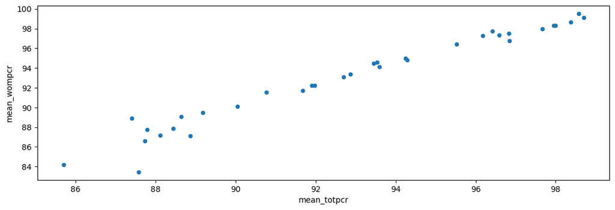

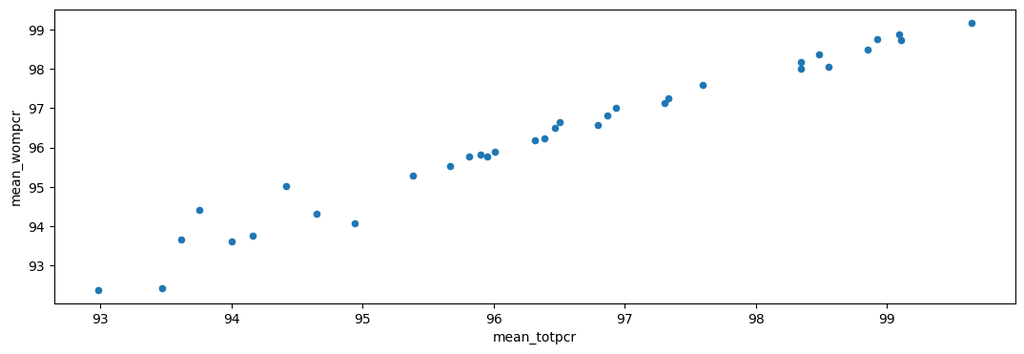

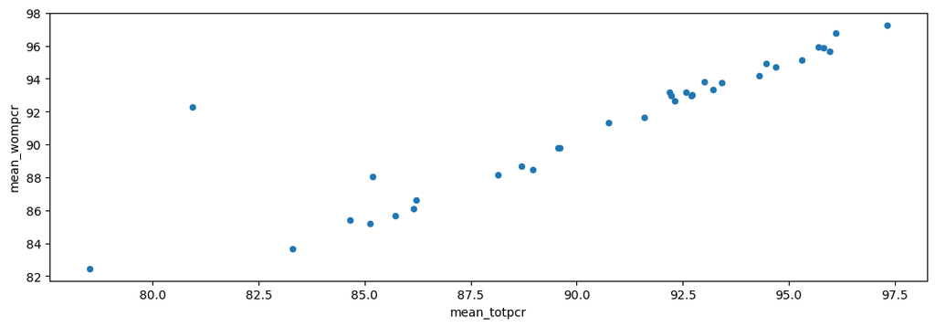

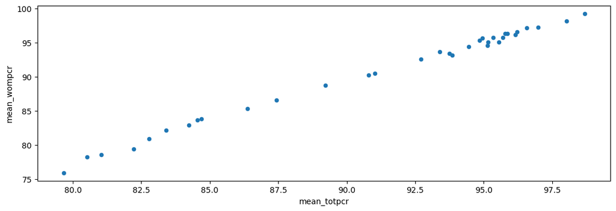

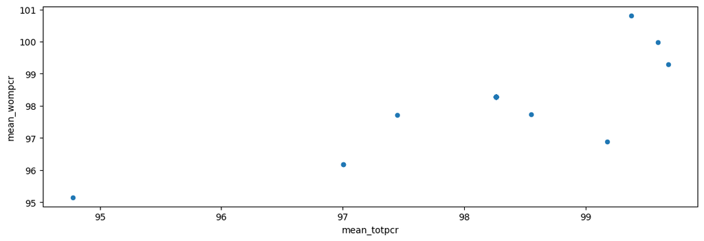

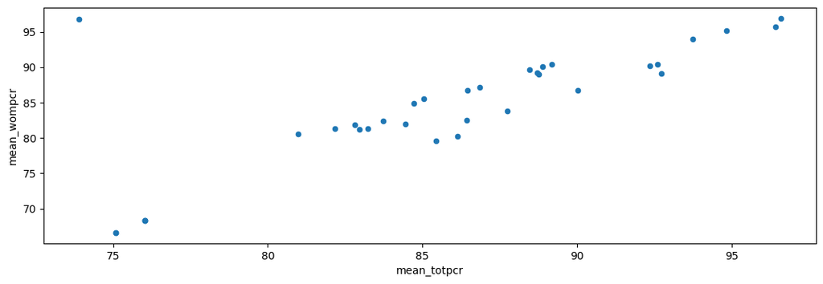

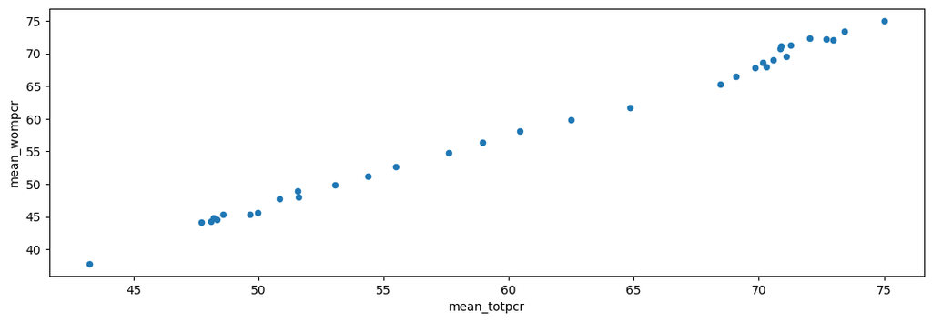

```python
plot_df.rename(columns={"Primary completion rate, total (% of relevant age group)": "mean_totpcr",
                        "Primary completion rate, female (% of relevant age group)": "mean_wompcr"}, inplace = True)
plot_df.groupby('Region').plot.scatter(x='mean_totpcr',y='mean_wompcr',figsize=(13,4))
plt.show()
```

Check if there is linear relationship in those values between total and female primary completion rate.

```python
plot_df_group = plot_df.groupby('Region')
for k, g in plot_df_group:
    model = ols('mean_totpcr ~ mean_wompcr', g)
    results = model.fit()
    print(results.summary())
```

```
                            OLS Regression Results
==============================================================================
Dep. Variable:            mean_totpcr   R-squared:                       0.962
Model:                            OLS   Adj. R-squared:                  0.961
Method:                 Least Squares   F-statistic:                     807.3
Date:                Sun, 15 Dec 2024   Prob (F-statistic):           2.84e-24
Time:                        03:02:26   Log-Likelihood:                -39.084
No. Observations:                  34   AIC:                             82.17
Df Residuals:                      32   BIC:                             85.22
Df Model:                           1
Covariance Type:            nonrobust
===============================================================================
                  coef    std err          t      P>|t|      [0.025      0.975]
-------------------------------------------------------------------------------
Intercept      14.4114      2.765      5.212      0.000       8.779      20.044
mean_wompcr     0.8433      0.030     28.413      0.000       0.783       0.904
==============================================================================
Omnibus:                       15.102   Durbin-Watson:                   1.787
Prob(Omnibus):                  0.001   Jarque-Bera (JB):               26.624
Skew:                           0.955   Prob(JB):                     1.65e-06
Kurtosis:                       6.892   Cond. No.                     1.91e+03
==============================================================================

Notes:
[1] Standard Errors assume that the covariance matrix of the errors is correctly specified.
[2] The condition number is large, 1.91e+03. This might indicate that there are
strong multicollinearity or other numerical problems.
                            OLS Regression Results
==============================================================================
Dep. Variable:            mean_totpcr   R-squared:                       0.970
Model:                            OLS   Adj. R-squared:                  0.969
Method:                 Least Squares   F-statistic:                     1047.
Date:                Sun, 15 Dec 2024   Prob (F-statistic):           5.09e-26
Time:                        03:02:26   Log-Likelihood:                -9.1907
No. Observations:                  34   AIC:                             22.38
Df Residuals:                      32   BIC:                             25.43
Df Model:                           1
Covariance Type:            nonrobust
===============================================================================
                  coef    std err          t      P>|t|      [0.025      0.975]
```

[output cut: 130 more lines]

```
Covariance Type:            nonrobust
===============================================================================
                  coef    std err          t      P>|t|      [0.025      0.975]
-------------------------------------------------------------------------------
Intercept       9.1752      0.626     14.653      0.000       7.900      10.451
mean_wompcr     0.8836      0.010     84.293      0.000       0.862       0.905
==============================================================================
Omnibus:                        1.127   Durbin-Watson:                   0.468
Prob(Omnibus):                  0.569   Jarque-Bera (JB):                1.108
Skew:                           0.382   Prob(JB):                        0.575
Kurtosis:                       2.553   Cond. No.                         314.
==============================================================================

Notes:
[1] Standard Errors assume that the covariance matrix of the errors is correctly specified.
```

From the scatterplots and summaries of OLS Regression Results above, except the intercept of "Europe & Central Asia" and "Latin America & Caribbean" might not be the predicted value by the model, since we can refuse the predicted values at a level $\alpha=0.05$, for all other regions there exist a linear relationship with the predicted intercept between total primary school completion rate and female completion rate.

```python
plot_df = df.loc[df['Region'] != '-'].groupby(["Region","yearID"])\
                                                [['School enrollment, primary, female (% gross)',\
                                                  'Primary completion rate, female (% of relevant age group)']].aggregate("mean")
plot_df.head()
```

| Region | yearID | School enrollment, primary, female (% gross) | Primary completion rate, female (% of relevant age group) |
| --- | --- | --- | --- |
| East Asia & Pacific | 1990 | 97.869307 | 88.889427 |
|  | 1991 | 98.906509 | 89.078600 |
|  | 1992 | 98.844266 | 83.452803 |
|  | 1993 | 99.614110 | 90.127908 |
|  | 1994 | 99.182130 | 87.101547 |

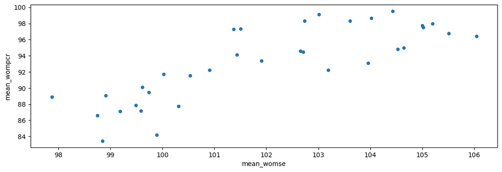

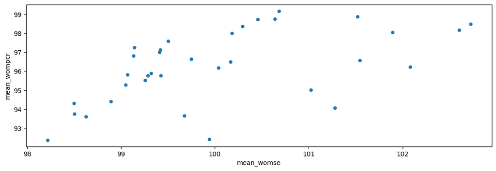

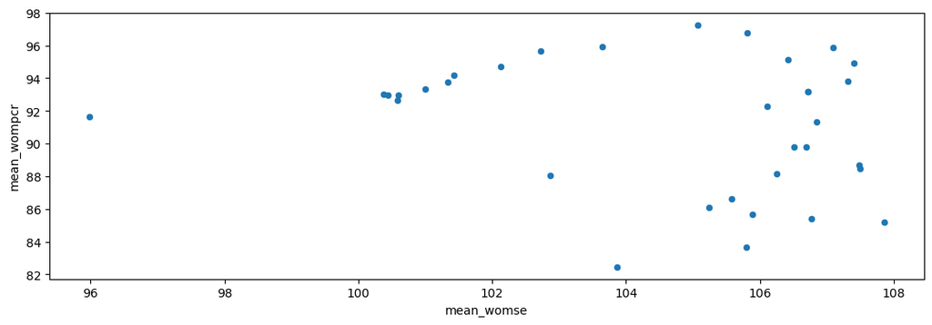

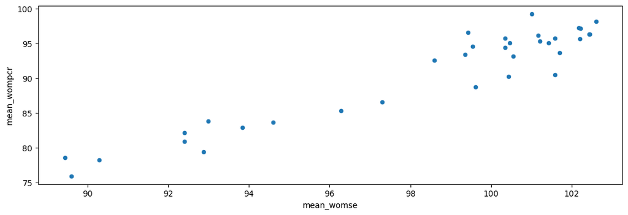

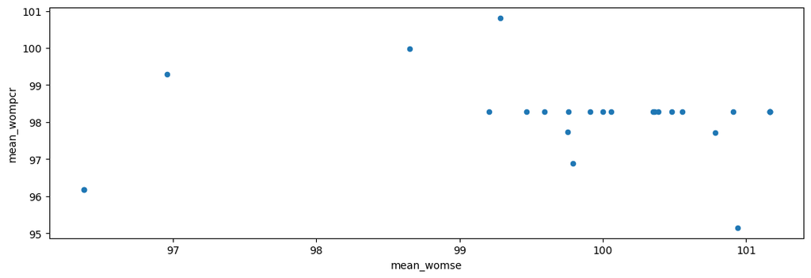

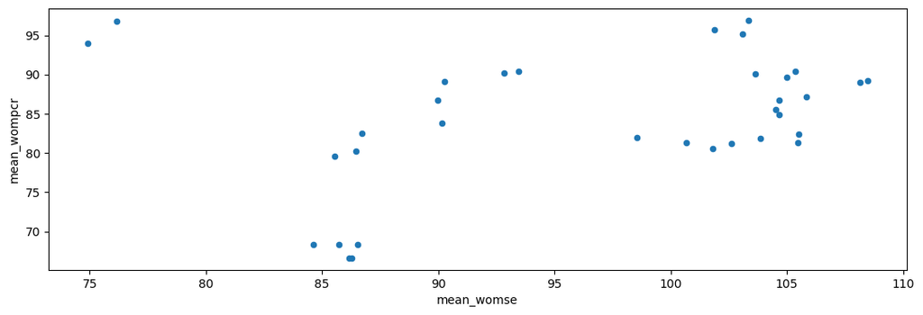

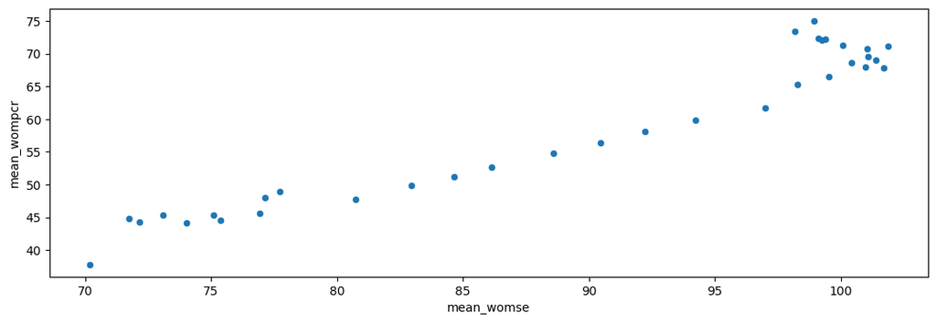

```python
plot_df.rename(columns={"School enrollment, primary, female (% gross)": "mean_womse",\
                        "Primary completion rate, female (% of relevant age group)": "mean_wompcr"}, inplace = True)
plot_df.groupby('Region').plot.scatter(x='mean_womse',y='mean_wompcr',figsize=(13,4))
plt.show()
```

Check if there is linear relationship in those values between female primary school enrollment and female primary completion rate.

```python
plot_df_group = plot_df.groupby('Region')
for k, g in plot_df_group:
    model = ols('mean_womse ~ mean_wompcr', g)
    results = model.fit()
    print(results.summary())
```

```
                            OLS Regression Results
==============================================================================
Dep. Variable:             mean_womse   R-squared:                       0.667
Model:                            OLS   Adj. R-squared:                  0.656
Method:                 Least Squares   F-statistic:                     64.05
Date:                Sun, 15 Dec 2024   Prob (F-statistic):           3.89e-09
Time:                        03:02:26   Log-Likelihood:                -58.302
No. Observations:                  34   AIC:                             120.6
Df Residuals:                      32   BIC:                             123.7
Df Model:                           1
Covariance Type:            nonrobust
===============================================================================
                  coef    std err          t      P>|t|      [0.025      0.975]
-------------------------------------------------------------------------------
Intercept      63.0443      4.866     12.955      0.000      53.132      72.957
mean_wompcr     0.4180      0.052      8.003      0.000       0.312       0.524
==============================================================================
Omnibus:                        1.991   Durbin-Watson:                   0.725
Prob(Omnibus):                  0.370   Jarque-Bera (JB):                1.231
Skew:                           0.140   Prob(JB):                        0.540
Kurtosis:                       2.111   Cond. No.                     1.91e+03
==============================================================================

Notes:
[1] Standard Errors assume that the covariance matrix of the errors is correctly specified.
[2] The condition number is large, 1.91e+03. This might indicate that there are
strong multicollinearity or other numerical problems.
                            OLS Regression Results
==============================================================================
Dep. Variable:             mean_womse   R-squared:                       0.294
Model:                            OLS   Adj. R-squared:                  0.272
Method:                 Least Squares   F-statistic:                     13.32
Date:                Sun, 15 Dec 2024   Prob (F-statistic):           0.000926
Time:                        03:02:26   Log-Likelihood:                -48.091
No. Observations:                  34   AIC:                             100.2
Df Residuals:                      32   BIC:                             103.2
Df Model:                           1
Covariance Type:            nonrobust
===============================================================================
                  coef    std err          t      P>|t|      [0.025      0.975]
```

[output cut: 130 more lines]

```
Covariance Type:            nonrobust
===============================================================================
                  coef    std err          t      P>|t|      [0.025      0.975]
-------------------------------------------------------------------------------
Intercept      33.4507      2.676     12.499      0.000      28.000      38.902
mean_wompcr     0.9552      0.045     21.321      0.000       0.864       1.046
==============================================================================
Omnibus:                        4.067   Durbin-Watson:                   0.295
Prob(Omnibus):                  0.131   Jarque-Bera (JB):                2.311
Skew:                          -0.401   Prob(JB):                        0.315
Kurtosis:                       2.007   Cond. No.                         314.
==============================================================================

Notes:
[1] Standard Errors assume that the covariance matrix of the errors is correctly specified.
```

From the scatterplots and summaries of OLS Regression Results above, except the slope of "Latin America & Caribbean" and "North America", for all other regions there exist a linear relationship with the predicted slope and intercept between female primary school enrollment rate and female primary school completion rate.

Now, the next guess is that primary completion rate is related to the Income Group.

```python
np.unique(df.loc[df['IncomeGroup'] != '-']['IncomeGroup'].values)
```

```
array(['High income', 'Low income', 'Lower middle income',
       'Upper middle income'], dtype=object)
```

```python
# plot a mean for every region
plot_df = df.loc[df['IncomeGroup'] != '-'].groupby(["IncomeGroup","yearID"])[['GDP per capita, PPP (current international $)',\
                                                                              'Primary completion rate, female (% of relevant age group)']]\
                                       .aggregate("mean")
plot_df.head()
```

| IncomeGroup | yearID | GDP per capita, PPP (current international $) | Primary completion rate, female (% of relevant age group) |
| --- | --- | --- | --- |
| High income | 1990 | 17065.133713 | 94.190805 |
|  | 1991 | 17392.062549 | 94.171681 |
|  | 1992 | 17974.899324 | 93.107316 |
|  | 1993 | 18585.967649 | 92.969019 |
|  | 1994 | 19449.166925 | 94.367092 |

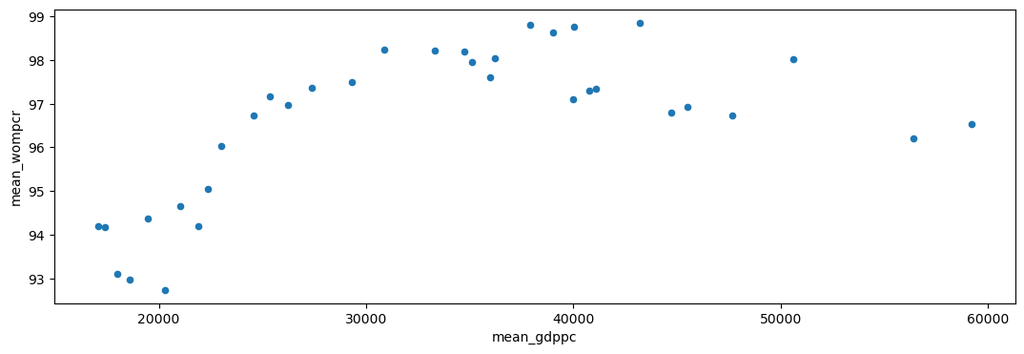

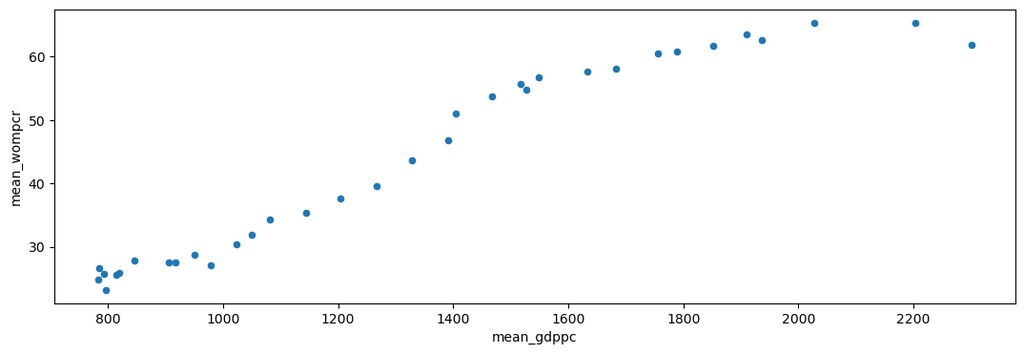

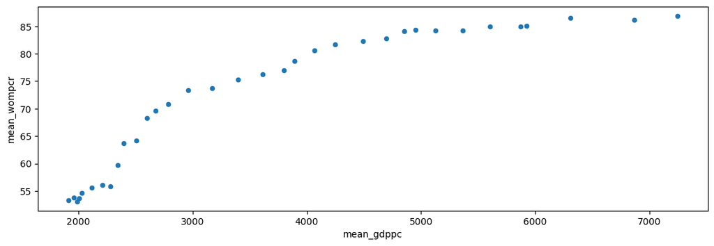

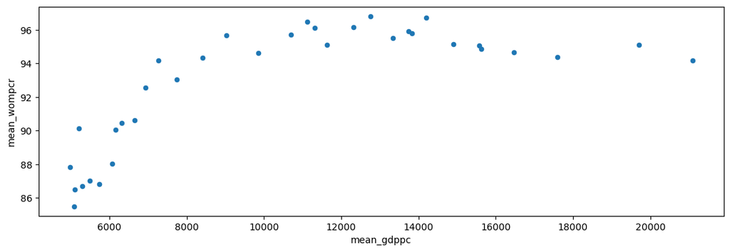

```python
plot_df.rename(columns={"GDP per capita, PPP (current international $)": "mean_gdppc",\
                        "Primary completion rate, female (% of relevant age group)": "mean_wompcr"}, inplace = True)
plot_df.groupby('IncomeGroup').plot.scatter(x='mean_gdppc',y='mean_wompcr',figsize=(13,4))
plt.show()
```

```python
# Check if there is linear relationship in those values between GDP per capita and female primary completion rate.
plot_df_group = plot_df.groupby('IncomeGroup')
for k, g in plot_df_group:
    model = ols('mean_gdppc ~ mean_wompcr', g)
    results = model.fit()
    print(results.summary())
```

```
                            OLS Regression Results
==============================================================================
Dep. Variable:             mean_gdppc   R-squared:                       0.383
Model:                            OLS   Adj. R-squared:                  0.364
Method:                 Least Squares   F-statistic:                     19.88
Date:                Sun, 15 Dec 2024   Prob (F-statistic):           9.50e-05
Time:                        03:02:26   Log-Likelihood:                -357.75
No. Observations:                  34   AIC:                             719.5
Df Residuals:                      32   BIC:                             722.6
Df Model:                           1
Covariance Type:            nonrobust
===============================================================================
                  coef    std err          t      P>|t|      [0.025      0.975]
-------------------------------------------------------------------------------
Intercept   -3.534e+05   8.67e+04     -4.077      0.000    -5.3e+05   -1.77e+05
mean_wompcr  4001.1007    897.360      4.459      0.000    2173.238    5828.963
==============================================================================
Omnibus:                       14.143   Durbin-Watson:                   0.213
Prob(Omnibus):                  0.001   Jarque-Bera (JB):               14.475
Skew:                           1.413   Prob(JB):                     0.000719
Kurtosis:                       4.493   Cond. No.                     5.27e+03
==============================================================================

Notes:
[1] Standard Errors assume that the covariance matrix of the errors is correctly specified.
[2] The condition number is large, 5.27e+03. This might indicate that there are
strong multicollinearity or other numerical problems.
                            OLS Regression Results
==============================================================================
Dep. Variable:             mean_gdppc   R-squared:                       0.935
Model:                            OLS   Adj. R-squared:                  0.933
Method:                 Least Squares   F-statistic:                     457.8
Date:                Sun, 15 Dec 2024   Prob (F-statistic):           1.59e-20
Time:                        03:02:26   Log-Likelihood:                -209.28
No. Observations:                  34   AIC:                             422.6
Df Residuals:                      32   BIC:                             425.6
Df Model:                           1
Covariance Type:            nonrobust
===============================================================================
                  coef    std err          t      P>|t|      [0.025      0.975]
```

[output cut: 49 more lines]

```
                  coef    std err          t      P>|t|      [0.025      0.975]
-------------------------------------------------------------------------------
Intercept   -7.709e+04   1.46e+04     -5.290      0.000   -1.07e+05   -4.74e+04
mean_wompcr   943.1438    156.780      6.016      0.000     623.793    1262.495
==============================================================================
Omnibus:                        9.729   Durbin-Watson:                   0.219
Prob(Omnibus):                  0.008   Jarque-Bera (JB):                8.500
Skew:                           1.111   Prob(JB):                       0.0143
Kurtosis:                       4.033   Cond. No.                     2.45e+03
==============================================================================

Notes:
[1] Standard Errors assume that the covariance matrix of the errors is correctly specified.
[2] The condition number is large, 2.45e+03. This might indicate that there are
strong multicollinearity or other numerical problems.
```

```python
# change plot_df and seek linear relationship between other factors and female primary completion rate
plot_df = df.loc[df['IncomeGroup'] != '-'].groupby(["IncomeGroup","yearID"])[['Primary completion rate, total (% of relevant age group)',\
                                                                              'Primary completion rate, female (% of relevant age group)']].aggregate("mean")
plot_df.head()
```

| IncomeGroup | yearID | Primary completion rate, total (% of relevant age group) | Primary completion rate, female (% of relevant age group) |
| --- | --- | --- | --- |
| High income | 1990 | 94.859804 | 94.190805 |
|  | 1991 | 94.286613 | 94.171681 |
|  | 1992 | 94.136171 | 93.107316 |
|  | 1993 | 93.692947 | 92.969019 |
|  | 1994 | 94.295637 | 94.367092 |

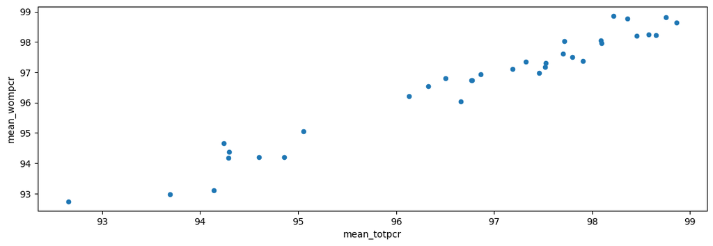

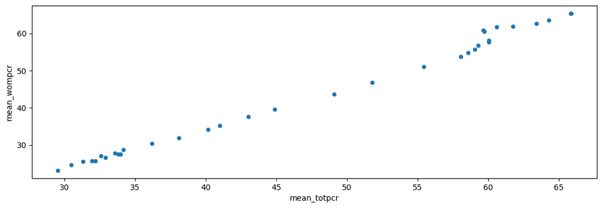

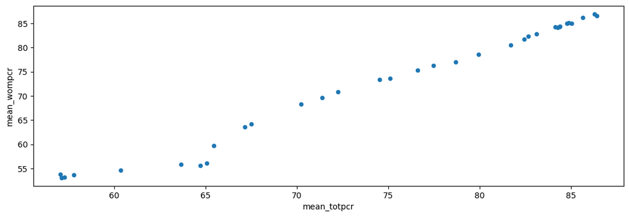

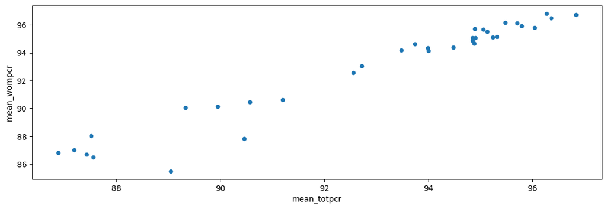

```python
plot_df.rename(columns={"Primary completion rate, total (% of relevant age group)": "mean_totpcr",\
                        "Primary completion rate, female (% of relevant age group)": "mean_wompcr"}, inplace = True)
plot_df.groupby('IncomeGroup').plot.scatter(x='mean_totpcr',y='mean_wompcr',figsize=(13,4))
plt.show()
```

```python
# Check if there is linear relationship in those values between total and female primary completion rate.
plot_df_group = plot_df.groupby('IncomeGroup')
for k, g in plot_df_group:
    model = ols('mean_totpcr ~ mean_wompcr', g)
    results = model.fit()
    print(results.summary())
```

```
                            OLS Regression Results
==============================================================================
Dep. Variable:            mean_totpcr   R-squared:                       0.961
Model:                            OLS   Adj. R-squared:                  0.960
Method:                 Least Squares   F-statistic:                     787.1
Date:                Sun, 15 Dec 2024   Prob (F-statistic):           4.19e-24
Time:                        03:02:27   Log-Likelihood:                -10.805
No. Observations:                  34   AIC:                             25.61
Df Residuals:                      32   BIC:                             28.66
Df Model:                           1
Covariance Type:            nonrobust
===============================================================================
                  coef    std err          t      P>|t|      [0.025      0.975]
-------------------------------------------------------------------------------
Intercept       6.7201      3.208      2.095      0.044       0.186      13.254
mean_wompcr     0.9318      0.033     28.056      0.000       0.864       0.999
==============================================================================
Omnibus:                        1.512   Durbin-Watson:                   1.318
Prob(Omnibus):                  0.470   Jarque-Bera (JB):                1.066
Skew:                          -0.126   Prob(JB):                        0.587
Kurtosis:                       2.170   Cond. No.                     5.27e+03
==============================================================================

Notes:
[1] Standard Errors assume that the covariance matrix of the errors is correctly specified.
[2] The condition number is large, 5.27e+03. This might indicate that there are
strong multicollinearity or other numerical problems.
                            OLS Regression Results
==============================================================================
Dep. Variable:            mean_totpcr   R-squared:                       0.993
Model:                            OLS   Adj. R-squared:                  0.993
Method:                 Least Squares   F-statistic:                     4552.
Date:                Sun, 15 Dec 2024   Prob (F-statistic):           4.46e-36
Time:                        03:02:27   Log-Likelihood:                -50.775
No. Observations:                  34   AIC:                             105.6
Df Residuals:                      32   BIC:                             108.6
Df Model:                           1
Covariance Type:            nonrobust
===============================================================================
                  coef    std err          t      P>|t|      [0.025      0.975]
```

[output cut: 49 more lines]

```
                  coef    std err          t      P>|t|      [0.025      0.975]
-------------------------------------------------------------------------------
Intercept      13.6492      3.303      4.133      0.000       6.921      20.377
mean_wompcr     0.8536      0.036     24.021      0.000       0.781       0.926
==============================================================================
Omnibus:                       16.117   Durbin-Watson:                   0.612
Prob(Omnibus):                  0.000   Jarque-Bera (JB):               21.539
Skew:                           1.247   Prob(JB):                     2.10e-05
Kurtosis:                       5.998   Cond. No.                     2.45e+03
==============================================================================

Notes:
[1] Standard Errors assume that the covariance matrix of the errors is correctly specified.
[2] The condition number is large, 2.45e+03. This might indicate that there are
strong multicollinearity or other numerical problems.
```

We can see from the above plots and OLS result summaries that all income groups have strong positive correlation between total and female primary completion rate.

```python
# Now it's the turn of female primary school enrollment versus female primary school completion rate.
plot_df = df.loc[df['IncomeGroup'] != '-'].groupby(["IncomeGroup","yearID"])\
                                                [['School enrollment, primary, female (% gross)',\
                                                  'Primary completion rate, female (% of relevant age group)']].aggregate("mean")
plot_df.head()
```

| IncomeGroup | yearID | School enrollment, primary, female (% gross) | Primary completion rate, female (% of relevant age group) |
| --- | --- | --- | --- |
| High income | 1990 | 99.845736 | 94.190805 |
|  | 1991 | 99.921435 | 94.171681 |
|  | 1992 | 98.897535 | 93.107316 |
|  | 1993 | 98.683318 | 92.969019 |
|  | 1994 | 99.232701 | 94.367092 |